# Marovoay–Ankarafantsika: Extended Econometric Analysis

### 9.4 GPS-based distance analysis and spatial gradient

```r
library(sf)

# GPS centroids hard-coded from 01_description.qmd (fokontany_centroids tribble)
site_gps <- tribble(
  ~site_id, ~Fokontany,         ~lat,       ~lon,
  "031",    "Bepako",           -16.163712, 46.658402,
  "032",    "Madiromiongana",   -16.086480, 46.749270,
  "033",    "Ampijoroa",        -16.233414, 46.477984,
  "034",    "Maroala",          -16.228857, 46.539738,
  "211",    "Avaradrano",       -17.805414, 48.469958,
  "212",    "Mangabe",          -17.879586, 48.405244,
  "213",    "Analamiranga",     -17.572375, 48.200017,
  "214",    "Ambatomanga",      -17.741178, 48.200647,
  "215",    "Feramanga Atsimo", -17.844153, 48.373383
)

pa_anka <- st_read(here::here("data", "ankarafantsika_protected_area.geojson"),
                   quiet = TRUE)

sites_sf <- site_gps |>
  st_as_sf(coords = c("lon", "lat"), crs = 4326) |>
  st_transform(st_crs(pa_anka))

dist_km <- as.numeric(st_distance(sites_sf, pa_anka)) / 1000

site_gps |>
  mutate(
    Role = case_when(
      site_id %in% MARO_TREATED  ~ "Treated (Marovoay)",
      site_id %in% MARO_CONTROL  ~ "Control (Marovoay)",
      TRUE                       ~ "Control (Alaotra)"
    ),
    `Distance to Anka. PA (km)` = round(dist_km, 1)
  ) |>
  select(site_id, Fokontany, Role, `Distance to Anka. PA (km)`) |>
  arrange(Role, site_id) |>
  gt() |>
  tab_style(
    style = list(cell_text(weight = "bold"), cell_fill(color = "#DCDCDC")),
    locations = cells_column_labels()
  ) |>
  tab_style(
    style = cell_fill(color = "#FFF3CD"),
    locations = cells_body(rows = Role == "Treated (Marovoay)")
  ) |>
  tab_source_note(
    md("*Source*: GPS centroids from 2025 OR survey; PA boundary from WDPA / `ankarafantsika_protected_area.geojson`.")
  )
```

Distance from site centroids to Ankarafantsika PA boundary

| site_id | Fokontany | Role | Distance to Anka. PA (km) |
| --- | --- | --- | --- |
| 211 | Avaradrano | Control (Alaotra) | 219.2 |
| 212 | Mangabe | Control (Alaotra) | 221.8 |
| 213 | Analamiranga | Control (Alaotra) | 181.4 |
| 214 | Ambatomanga | Control (Alaotra) | 197.1 |
| 215 | Feramanga Atsimo | Control (Alaotra) | 216.7 |
| 033 | Ampijoroa | Control (Marovoay) | 11.3 |
| 034 | Maroala | Control (Marovoay) | 5.6 |
| 031 | Bepako | Treated (Marovoay) | 5.2 |
| 032 | Madiromiongana | Treated (Marovoay) | 11.7 |

*Source*: GPS centroids from 2025 OR survey; PA boundary from WDPA / `ankarafantsika_protected_area.geojson`.

**Implications for spatial RDD**: With household-level GPS from the 2025 wave, a regression discontinuity design using distance to the PA boundary as the running variable is directly feasible. Households within 2 km of the PA edge (pure treatment zone) could be compared to those 5–15 km away, controlling for site fixed effects. This would sharply identify the *local* treatment effect at the boundary and is the highest-priority extension for a follow-up study.

### 9.5 Additional strategies to gain statistical power

**TipRecommended power strategies (priority order)**

## 10 Robustness Checks

### 10.1 Sensitivity to 2005 exclusion

2005 is excluded from preferred specifications because Marovoay ran a tracking survey of a non-random subset of households (site 032 was not covered). The comparison below shows how inclusion of 2005 affects TWFE estimates:

```r
# Maro-only with 2005 included (panel_maro includes 2005 since hist panel only drops via filter)
fit_twfe_with05 <- feols(
  ln_revtot_w ~ treatment | j5 + year,
  data    = panel_maro |> filter(year >= 1998, year <= 2014),
  cluster = ~site_id
)

etable(fit_twfe_revtot, fit_twfe_with05,
       headers = c("2005 excluded (preferred)", "2005 included"),
       keep    = "treatment")
```

[output not shown]

### 10.2 In-space placebo (Alaotra sites as pseudo-treated)

Assign each Alaotra site the same 2003 treatment date and run gsynth. The actual Marovoay ATT should lie outside the distribution of placebo ATTs.

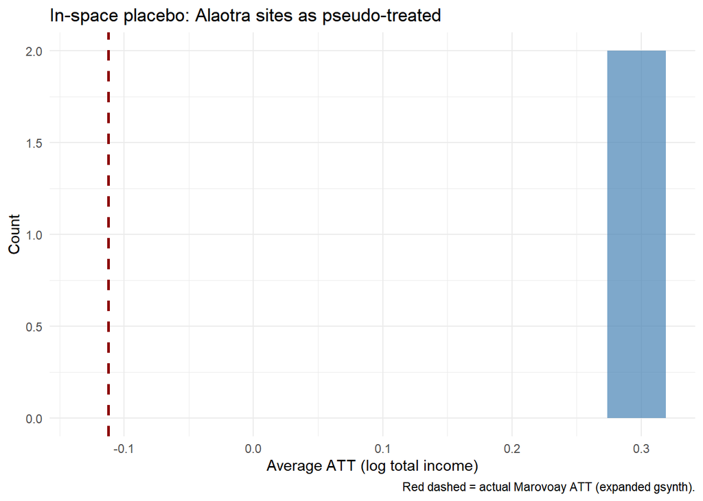

```r
run_placebo_gs <- function(pseudo_site, data) {
  d <- data |>
    mutate(
      treatment = as.integer(site_id == pseudo_site & year >= TREAT_YEAR)
    )
  tryCatch(
    gsynth(ln_revtot_w ~ treatment,
           data = d, index = c("site_id", "year"),
           se = FALSE, r = 0, CV = FALSE, force = "two-way",
           parallel = FALSE, min.T0 = 4, seed = 2139),
    error = function(e) NULL
  )
}

placebo_gs <- map(ALAOTRA_ALL, ~ run_placebo_gs(.x, panel_site_expanded))
names(placebo_gs) <- ALAOTRA_ALL

placebo_att_df <- imap_dfr(placebo_gs, function(res, site) {
  if (!is.null(res))
    tibble(site = site, ATT = mean(res$att.avg, na.rm = TRUE), is_treated = FALSE)
})

actual_att_val <- tryCatch(mean(gs_exp$att.avg, na.rm = TRUE), error = function(e) NA_real_)

placebo_att_all <- bind_rows(
  placebo_att_df,
  tibble(site = "Marovoay (actual)", ATT = actual_att_val, is_treated = TRUE)
)

ggplot(placebo_att_all |> filter(!is_treated), aes(x = ATT)) +
  geom_histogram(bins = 10, fill = "steelblue", alpha = 0.7) +
  geom_vline(xintercept = actual_att_val, color = "darkred",
             linetype = "dashed", linewidth = 1) +
  labs(x = "Average ATT (log total income)", y = "Count",
       title = "In-space placebo: Alaotra sites as pseudo-treated",
       caption = "Red dashed = actual Marovoay ATT (expanded gsynth).") +
  theme_minimal()
```